# Alex Project2 Code Testing

Xianming Tan

2024-06-17

## Introduction

To understand Alex’s code for project 2.

See https://github.com/aquinter96/Dissertation_Projects/tree/main/Project_2/Initial_Estimate_Comparisons_Code.

We first work on `Truth_Inits.R`.

**Completed**

- wrap into several functions
  - model parameters setup …
    - `Model_Meta_Param.R` (dimensions)
    - `Model_Matrix_Param.R` (matrices like A1/A2/…)
  - data generation
    - `Data_Generation.R` (a function)
  - estimation
    - `_EMAlgXAdLassoCV_00.R`
    - `_EMAlgYAdLassoCV_00.R`
  - testing data and results
    - `TestData.RData`
  - to re-organize: `_EMAlgYAdLassoCV_00.R`
    - See `EMAlgYAdLassoCV_01.R`
    - Main function `EMAlgYAdLasso()`
    - The E-step part: EMAlgYAdLasso_EStep()
    - The M-step part: EMAlgYAdLasso_MStep()

**To dos**

- estimation functions are too long, will divide it into multiple parts
  - `_EMAlgXAdLassoCV_00.R` (X-part … )

## Setup

### Load libraries

```r
library(MASS)
library(pracma)
library(psych)
library(r.jive)
```

### Random seed

```r
## args <- commandArgs(TRUE)
# datset <- 1 ## as.numeric(args[1])
set.seed(12543)
```

### To initialize parameters

The model for Paper 2 is described in overleaf and in `Paper2 overview.md` (obsidian note)

In the below code, we setup the parameters for the model

**Some comments**

```r
code_dir <- "C:/Users/tanxi/Downloads/Dissertation_Projects-main/Project_2/"
source(file = paste0(code_dir, "Model_Meta_Param.R") )
source(file = paste0(code_dir, "Model_Matrix_Param.R") )
```

### To generate simulated data

- Sample size: $n = 1000$.
- In this part, we generate $X,Y$
- We wrap this part to a R function `Data_Generation` and saved in file `Data_Generation.R`

```r
source(file = paste0(code_dir, "Data_Generation.R") )

set.seed(123456)
MyData <- Data_Generation(n = 1000, Model_Params=Model_Params)
```

### True values of G1-G4, for intermediate checking …

```r
G1t <- Model_Params$Gamma1%*%Model_Params$Theta + Model_Params$Delta1%*%Model_Params$Pi1
G2t <- Model_Params$Gamma2%*%Model_Params$Theta + Model_Params$Delta2%*%Model_Params$Pi2
G3t <- Model_Params$Gamma1%*%Model_Params$Psi + Model_Params$Delta1%*%Model_Params$Omega1
G4t <- Model_Params$Gamma2%*%Model_Params$Psi + Model_Params$Delta2%*%Model_Params$Omega2
Gt <- rbind(cbind(G1t, G3t), cbind(G2t, G4t))

D <- cov(cbind(t( MyData$X1), t(MyData$X2)))
```

### To get initial values on A/B matrices for the X part …

- In this version, we used the true parameter values as the initial values for EM algorithm

## EM algorithms

These parameters are: $A_1, A_2, B_1, B_2, \Phi_R, \Phi_{S1}, \Phi_{S2}$

The following code chunk defines a function `EMAlgXAdLassoCV` to estimate these parameters given data $X$ and initial parameters.

We first move function `EMAlgXAdLassoCV` to R file “*EMAlgXAdLassoCV_00.R” (this will not replaced by other files not starting with ”*”).

### To test the EM algorithm for the X part .

```r
source(file = paste0(code_dir, "_EMAlgXAdLassoCV_00.R") )
```

To do: to re-organize the EM algorithm for the X-part.

```r
time0 <- proc.time()
##############################################################################################################################################
## This test fix tuning parameter at 0. This means, this compuation is really intensive and slow (8 minutes for one X data). This is weird.
##############################################################################################################################################
test <- EMAlgXAdLassoCV(Xpanel = list(t(MyData$X1), t(MyData$X2)), x_joint =  meta_param$m, x_indiv = c(meta_param$u1, meta_param$u2),
                        Ainits = list(Model_Params$A1, Model_Params$A2), Binits = list(Model_Params$B1, Model_Params$B2),
                        vcovinits = list(Model_Params$PhiR, Model_Params$PhiS1, Model_Params$PhiS2, Model_Params$Phi11, Model_Params$Phi12),
                        tuningpA = 0, tuningpB = 0,
                        weightsA = list(Model_Params$A1, Model_Params$A2), weightsB = list(Model_Params$B1, Model_Params$B2)  )
```

```
## [1] "CV done"
```

```r
time1 <- proc.time()
timeDiff <- time1 - time0 ## 8 minutes for one data set (X part only)  ...; 150s (2.5 minutes)

timeDiff
```

```
##    user  system elapsed
##  124.00    4.00  137.29
```

### To test the EM step for the Y part

- The initials from the ADAM max sometimes not good, and hence EM did not improve much …
- I think that we used the true parameter values as the initial value for EM algorithm, right?

```r
# source(file = paste0(code_dir, "_EMAlgYAdLassoCV_00.R") )
source(file = paste0(code_dir, "EMAlgYAdLassoCV_01.R"))
```

- The Y-part is re-organized into several functions …

```r
time0 <- proc.time()
## fixed tuningpGamma,  tuningpDelta
## using true A1/A2/B1/B2 as initials ...
## Example:
myEMRes <-       EMAlgYAdLasso(Data = MyData,
                              initial_Model_Param = Model_Params,
                              tuningpGamma = 0,
                              tuningpDelta = 0,
                              weightsGamma = list(Model_Params$Gamma1, Model_Params$Gamma2),
                              weightsDelta = list(Model_Params$Delta1, Model_Params$Delta2) )

time1 <- proc.time()
timeDiff <- time1 - time0

timeDiff
```

```
##    user  system elapsed
##   19.91    2.08   24.05
```

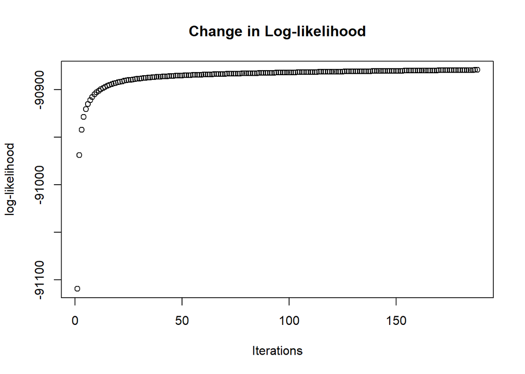

```r
plot(myEMRes$log.Like, main = "Change in Log-likelihood", xlab = "Iterations", ylab = "log-likelihood")
```

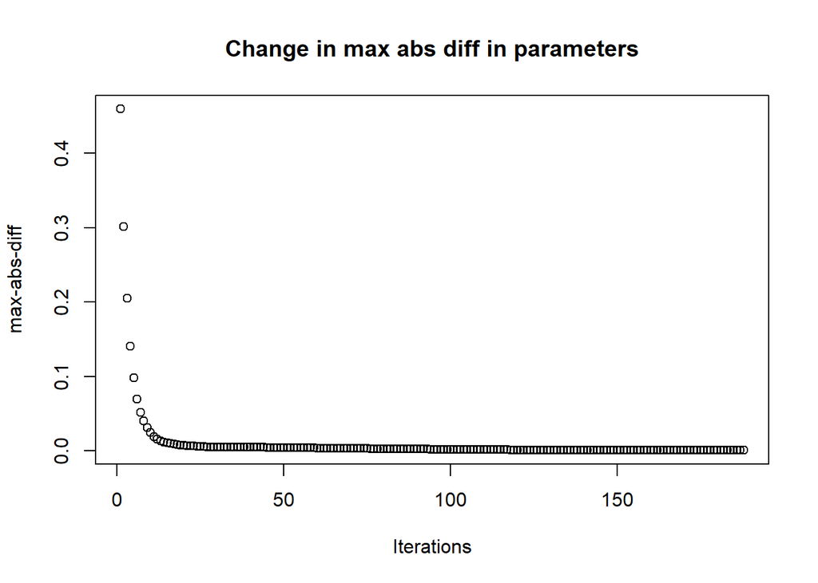

```r
plot(myEMRes$diffList, main = "Change in max abs diff in parameters", xlab = "Iterations", ylab = "max-abs-diff")
```

```r
# save(test, test2, meta_param, Model_Params, MyData, file=paste0(code_dir,  "TestData.RData"))
```